# InitialResult

CIND820 - Final Project

> An Analysis of Factors Impacting the Stock Market Price

> Initial Results [Import Data/Data Cleaning/Visualization/Modelling]

```
Student: Stella Hao | Supervisor: Dr. Ashok Bhowmick
```

1. Import required libraries and import raw data for consumer price index, gross domesitc income, housing price, prime rate, and TSX price.

```python
# import required library
!pip install pandas_ta
import pandas_ta as ta
import pandas as pd
import numpy as np
from pandas import datetime
import matplotlib.pyplot as plt
import seaborn as sns
import matplotlib.pyplot as plt
import numpy as np
from statsmodels.tsa.seasonal import seasonal_decompose

# import data
def parser(x):
	return datetime.strptime(x, '%Y-%m-%d')

cpi = pd.read_csv('cpi.csv',header=0, parse_dates=[0], index_col=0, squeeze=True, date_parser=parser)
gdi = pd.read_csv('gdi.csv',header=0, parse_dates=[0], index_col=0, squeeze=True, date_parser=parser)
housing = pd.read_csv('housing.csv',header=0, parse_dates=[0], index_col=0, squeeze=True, date_parser=parser)
prime = pd.read_csv('prime_rate.csv',header=0, parse_dates=[0], index_col=0, squeeze=True, date_parser=parser)
tsx = pd.read_csv('tsx_original.csv',header=0, parse_dates=[0], index_col=0, squeeze=True, date_parser=parser)
```

1. Remove null values from TSX data, and add moving averages MA10, MA50, MA100, and MA200. Drop null values after adding in the moving averages and keep only the interested column of Date and Close price.

```python
# For stock return data, drop records for null values
tsx_new = tsx.dropna()
# Add technical indicators (moving average 10, 50, 100, 200)
tsx_new.ta.sma(close='Close', length=10, append=True)
tsx_new.ta.sma(close='Close', length=50, append=True)
tsx_new.ta.sma(close='Close', length=100, append=True)
tsx_new.ta.sma(close='Close', length=200, append=True)
# drop null values after adding technical indicators
tsx_new1 = tsx_new.dropna()
# remove unrequired columns
tsx_new1 = tsx_new1.drop(columns=['Open','High','Low','Adj Close','Volume'])
```

1. Check correlation

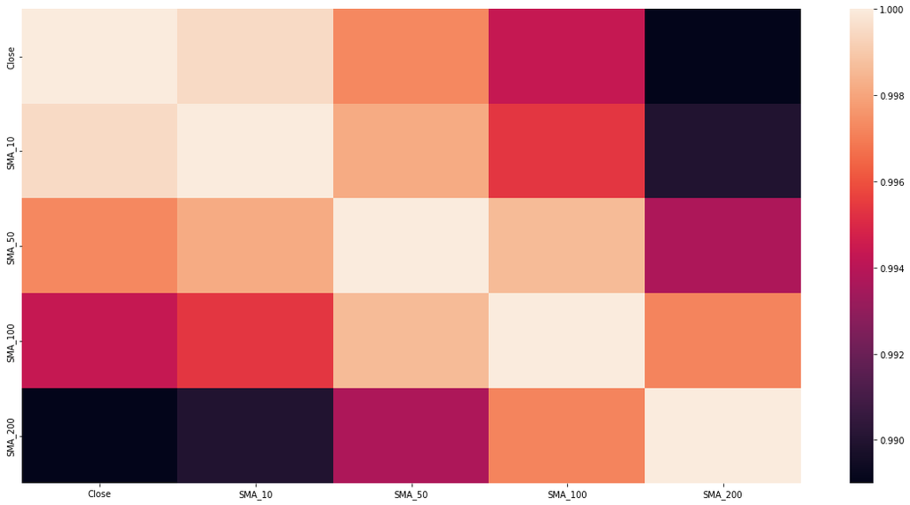

```python
# calculate the correlation matrix
corr = tsx_new1.corr()

# plot the heatmap
sns.heatmap(corr,
        xticklabels=corr.columns,
        yticklabels=corr.columns)

#Based on the result all values are highly correlated as expected.
```

1. Visualize the data

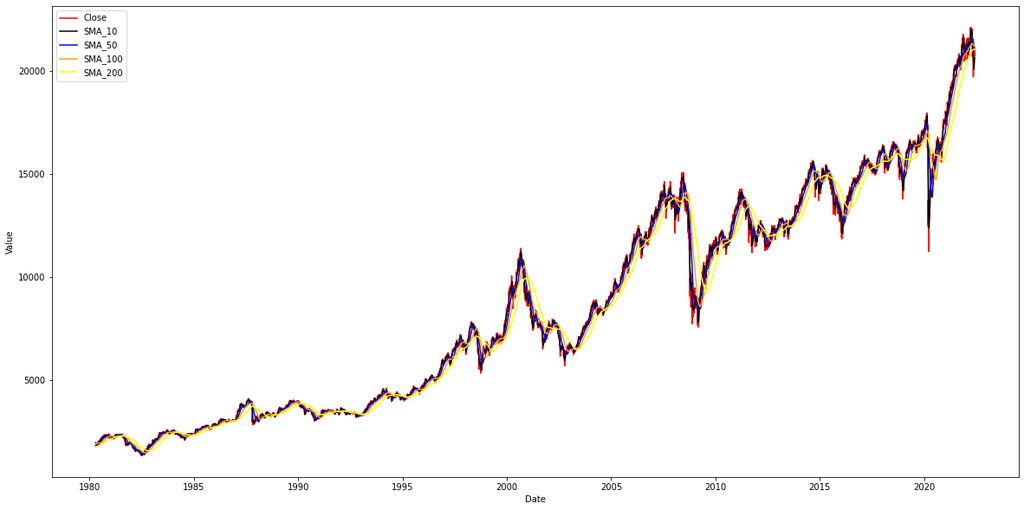

```python
fig, ax = plt.subplots()

# Plot linear sequence, and set tick labels to the same color
ax.plot(tsx_new1['Close'], color='red',label='Close')
ax.plot(tsx_new1['SMA_10'], color='black',label='SMA_10')
ax.plot(tsx_new1['SMA_50'], color='blue',label='SMA_50')
ax.plot(tsx_new1['SMA_100'], color='orange',label='SMA_100')
ax.plot(tsx_new1['SMA_200'], color='yellow',label='SMA_200')
ax.tick_params(axis='y', labelcolor='black')

plt.xlabel("Date")
plt.ylabel("Value")
ax.legend(loc='upper left')
plt.show()

#Based on the graph, the close price, sma 10, sma 50, sma 100, and sma 200 closely tracks each other as expected.
#The close prices shows a large dip in 2020 whereas the SMA 10 shows a slightly less dip, followed by SMA 50, SMA 100 and SMA 200.
#This trend is due to the smoothing effect of the moving average which have smoothed out the dip across the relative moving average days.
```

1. Check if seasonality exist in the dataset

```python
#Seasonality Check code
def decompose(df, column_name, frequency):
    """
    A function that returns the trend, seasonality and residual captured by applying both multiplicative and
    additive model.
    """
    result_mul = seasonal_decompose(df[column_name], model='multiplicative', extrapolate_trend = 'freq',freq=frequency)
    result_add = seasonal_decompose(df[column_name], model = 'additive', extrapolate_trend='freq',freq=frequency)

    plt.rcParams.update({'figure.figsize': (20, 10)})
    result_mul.plot().suptitle('Multiplicative Decompose', fontsize=30)
    result_add.plot().suptitle('Additive Decompose', fontsize=30)
    plt.show()
    return result_mul, result_add
```

1. As we can see, setting the time series frequency as 48, the trend was well captured. Also, if we look at the residuals plot, we can see no well-defined pattern for the multiplicative decompose. The additive depose shows a flat residual at the earlier years with an increasing trend to the recent years. Therefore, we will use multiplicative decompose and we can say our time series was well decomposed into its components. The residuals are also interesting, showing periods of high variability during the rapid falls and rise in the series.

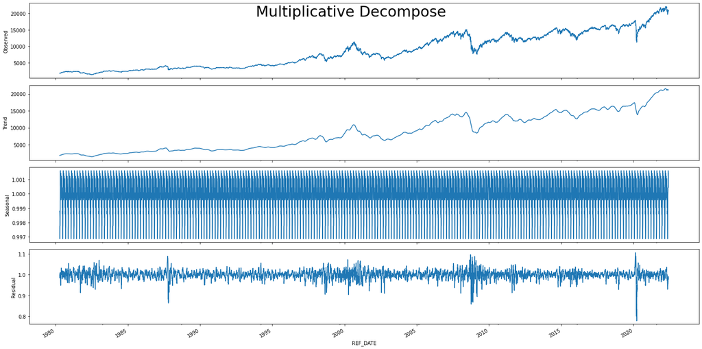

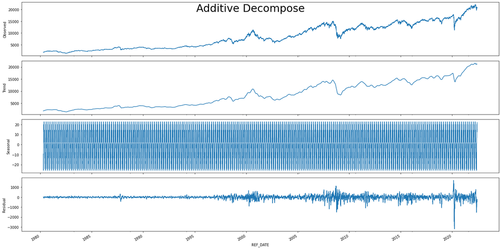

```python
#Seasonality check for Close price
result_mul, result_add = decompose(tsx_new1, 'Close',48)
```

1. Add decomposed seasonality data as a variable to the dataset

```python
#add seasonality data in the dataset
df_reconstructed = pd.concat([result_mul.seasonal, result_mul.trend, result_mul.resid, result_mul.observed], axis = 1)
df_reconstructed.columns = ['close_seas', 'close_trend', 'close_resid', 'close_actual_values']
tsx_new_season = pd.merge(tsx_new1, df_reconstructed, on="REF_DATE")
```

1. Check correlation again

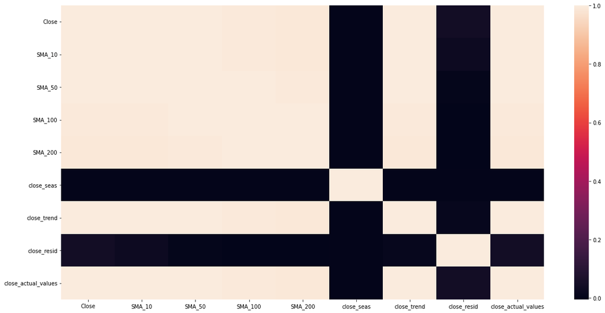

```python
# calculate the correlation matrix
corr = tsx_new_season.corr()

# plot the heatmap
sns.heatmap(corr,
        xticklabels=corr.columns,
        yticklabels=corr.columns)
```

1. Drop seasonality and residual as these do not show correlation

```python
#drop duplicate value close_actual_values
tsx_new_season = tsx_new_season.drop(columns=['close_actual_values','close_seas','close_resid'])
```

1. Convert CPI, GDI, housing, and prime rate to be the same frequency as the daily stock price data.

```python
#Convert cpi, gdi, housing, and prime rate into daily data
cpi_fill=cpi.resample('D').ffill()
cpi_time = cpi_fill.interpolate(method='time')

gdi_fill = gdi.resample('D')
gdi_time = gdi_fill.interpolate(method='time')

housing_fill = housing.resample('D')
housing_time = housing_fill.interpolate(method='time')

prime_fill = prime.resample('D')
prime_time = prime_fill.interpolate(method='time')

#Merge data set into one dataframe

final_dt = pd.merge(tsx_new_season, cpi_time, on="REF_DATE")
final_dt = pd.merge(final_dt, gdi_time, on="REF_DATE")
final_dt = pd.merge(final_dt, housing_time, on="REF_DATE")
final_dt = pd.merge(final_dt, prime_time, on="REF_DATE")
```

1. Visualize the final dataset

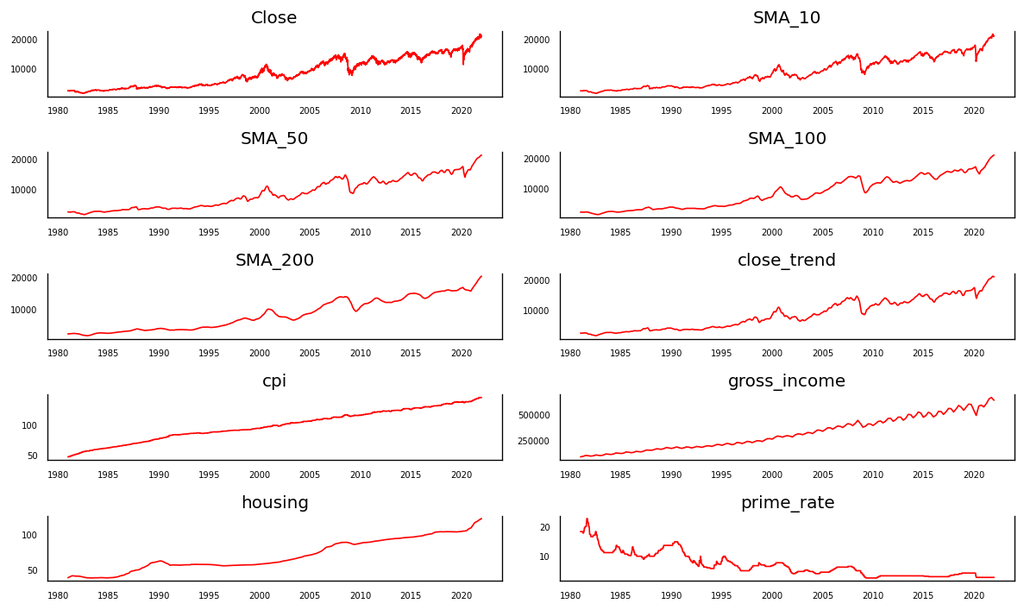

```python
#Visualize the final dataset
fig, axes = plt.subplots(nrows=5, ncols=2, dpi=120, figsize=(10,6))
for i, ax in enumerate(axes.flatten()):
    data = final_dt[final_dt.columns[i]]
    ax.plot(data, color='red', linewidth=1)
    # Decorations
    ax.set_title(final_dt.columns[i])
    ax.xaxis.set_ticks_position('none')
    ax.yaxis.set_ticks_position('none')
    ax.spines["top"].set_alpha(0)
    ax.tick_params(labelsize=6)

plt.tight_layout();
#all variable shows upward trend except for prime rate which is showing a downward trend
```

1. Visualize data on the same graph

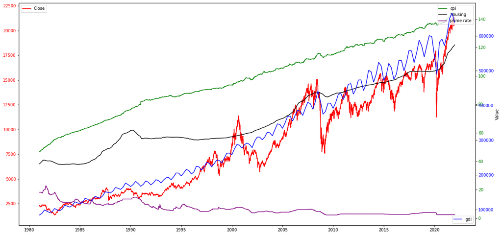

```python
#Graph Close price, cpi, gdi, housing, prime rate on the same graph
fig, ax = plt.subplots()

# Plot Close price, and set tick labels color
ax.plot(final_dt['Close'], color='red',label='Close')
ax.tick_params(axis='y', labelcolor='red')

# Generate new Axes instances, on the twin-X axes
ax2 = ax.twinx()
ax3 = ax.twinx()

# Plot other variables and change tick color
ax2.plot(final_dt['cpi'], color='green',label='cpi')
ax2.tick_params(axis='y', labelcolor='green')
ax2.plot(final_dt['housing'], color='black',label='housing')
ax2.plot(final_dt['prime_rate'], color='purple',label='prime rate')

ax3.plot(final_dt['gross_income'], color='blue',label='gdi')
ax3.tick_params(axis='y', labelcolor='blue')

plt.xlabel("Date")
plt.ylabel("Value")
ax.legend(loc='upper left')
ax2.legend(loc='upper right')
ax3.legend(loc='lower right')
plt.show()

#Close price y-scale in color red
#cpi, housing, prime rate y-scale in color green
#gross domestic income (GDI) y-scale in color blue
#all data shows upward trend execpt prime rate
```

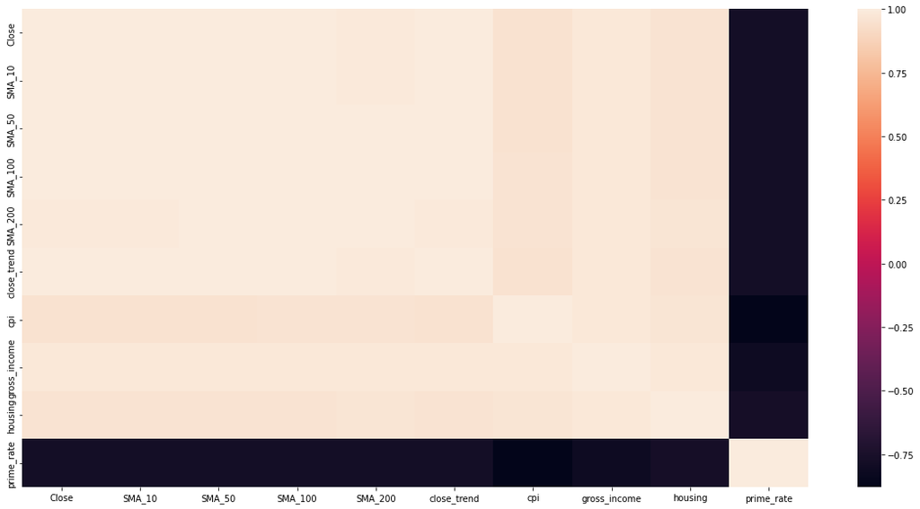

```python
# calculate the correlation matrix
corr_final_dt = final_dt.corr()

# plot the heatmap
sns.heatmap(corr_final_dt,
        xticklabels=corr_final_dt.columns,
        yticklabels=corr_final_dt.columns)
```

1. Save final data

```python
import os
os.makedirs('folder/', exist_ok=True)
final_dt.to_csv('folder/final_dt.csv')
```

1. Split training and testing data

```python
#training and testing dataset. Setting the testing dataset to be the last 21 days.
nobs = 21 #21 days
df_train, df_test = final_dt[0:-nobs], final_dt[-nobs:]

# Check size
print(df_train.shape)
print(df_test.shape)
```

```
(10277, 10)
(21, 10)
```

1. Function for stationary test as the VAR model expects the input variable to be stationary.

```python
#stationary test
def adfuller_test(series, signif=0.05, name='', verbose=False):
#Perform ADFuller to test for Stationarity of given dataset and print report
    r = adfuller(series, autolag='AIC')
    output = {'test_statistic':round(r[0], 4), 'pvalue':round(r[1], 4), 'n_lags':round(r[2], 4), 'n_obs':r[3]}
    p_value = output['pvalue']
    def adjust(val, length= 6): return str(val).ljust(length)

    # Print Summary
    print(f'    Augmented Dickey-Fuller Test on "{name}"', "\n   ", '-'*47)
    print(f' Null Hypothesis: Data has unit root. Non-Stationary.')
    print(f' Significance Level    = {signif}')
    print(f' Test Statistic        = {output["test_statistic"]}')
    print(f' No. Lags Chosen       = {output["n_lags"]}')

    for key,val in r[4].items():
        print(f' Critical value {adjust(key)} = {round(val, 3)}')

    if p_value <= signif:
        print(f" => P-Value = {p_value}. Rejecting Null Hypothesis.")
        print(f" => Series is Stationary.")
    else:
        print(f" => P-Value = {p_value}. Weak evidence to reject the Null Hypothesis.")
        print(f" => Series is Non-Stationary.")
```

1. Test for stationary - Data shows non-stationary for all the variables

```python
#import stats model
from statsmodels.tsa.stattools import adfuller
# ADF Test on each column of the training dataset
for name, column in df_train.iteritems():
    adfuller_test(column, name=column.name)
    print('\n')
```

```
    Augmented Dickey-Fuller Test on "Close"
    -----------------------------------------------
 Null Hypothesis: Data has unit root. Non-Stationary.
 Significance Level    = 0.05
 Test Statistic        = 0.0947
 No. Lags Chosen       = 39
 Critical value 1%     = -3.431
 Critical value 5%     = -2.862
 Critical value 10%    = -2.567
 => P-Value = 0.9657. Weak evidence to reject the Null Hypothesis.
 => Series is Non-Stationary.


    Augmented Dickey-Fuller Test on "SMA_10"
    -----------------------------------------------
 Null Hypothesis: Data has unit root. Non-Stationary.
 Significance Level    = 0.05
 Test Statistic        = 0.2357
 No. Lags Chosen       = 39
 Critical value 1%     = -3.431
 Critical value 5%     = -2.862
 Critical value 10%    = -2.567
 => P-Value = 0.9742. Weak evidence to reject the Null Hypothesis.
 => Series is Non-Stationary.


    Augmented Dickey-Fuller Test on "SMA_50"
    -----------------------------------------------
 Null Hypothesis: Data has unit root. Non-Stationary.
 Significance Level    = 0.05
 Test Statistic        = 0.5058
 No. Lags Chosen       = 39
 Critical value 1%     = -3.431
 Critical value 5%     = -2.862
 Critical value 10%    = -2.567
 => P-Value = 0.985. Weak evidence to reject the Null Hypothesis.
 => Series is Non-Stationary.


    Augmented Dickey-Fuller Test on "SMA_100"
```

[output cut: 73 more lines]

```
 => P-Value = 0.9968. Weak evidence to reject the Null Hypothesis.
 => Series is Non-Stationary.


    Augmented Dickey-Fuller Test on "prime_rate"
    -----------------------------------------------
 Null Hypothesis: Data has unit root. Non-Stationary.
 Significance Level    = 0.05
 Test Statistic        = -2.672
 No. Lags Chosen       = 36
 Critical value 1%     = -3.431
 Critical value 5%     = -2.862
 Critical value 10%    = -2.567
 => P-Value = 0.079. Weak evidence to reject the Null Hypothesis.
 => Series is Non-Stationary.
```

1. In order to convert to stationary data, conduct first difference on the dataset.

```python
# 1st difference
final_differenced = df_train.diff().dropna()
```

1. Check for data stationary again after first difference. All of the variables are stationary after 1st difference.

```python
# ADF Test on each column of 1st Differences Dataframe
for name, column in final_differenced.iteritems():
    adfuller_test(column, name=column.name)
    print('\n')
```

```
    Augmented Dickey-Fuller Test on "Close"
    -----------------------------------------------
 Null Hypothesis: Data has unit root. Non-Stationary.
 Significance Level    = 0.05
 Test Statistic        = -15.74
 No. Lags Chosen       = 38
 Critical value 1%     = -3.431
 Critical value 5%     = -2.862
 Critical value 10%    = -2.567
 => P-Value = 0.0. Rejecting Null Hypothesis.
 => Series is Stationary.


    Augmented Dickey-Fuller Test on "SMA_10"
    -----------------------------------------------
 Null Hypothesis: Data has unit root. Non-Stationary.
 Significance Level    = 0.05
 Test Statistic        = -15.9078
 No. Lags Chosen       = 39
 Critical value 1%     = -3.431
 Critical value 5%     = -2.862
 Critical value 10%    = -2.567
 => P-Value = 0.0. Rejecting Null Hypothesis.
 => Series is Stationary.


    Augmented Dickey-Fuller Test on "SMA_50"
    -----------------------------------------------
 Null Hypothesis: Data has unit root. Non-Stationary.
 Significance Level    = 0.05
 Test Statistic        = -13.2186
 No. Lags Chosen       = 39
 Critical value 1%     = -3.431
 Critical value 5%     = -2.862
 Critical value 10%    = -2.567
 => P-Value = 0.0. Rejecting Null Hypothesis.
 => Series is Stationary.


    Augmented Dickey-Fuller Test on "SMA_100"
```

[output cut: 73 more lines]

```
 => P-Value = 0.0. Rejecting Null Hypothesis.
 => Series is Stationary.


    Augmented Dickey-Fuller Test on "prime_rate"
    -----------------------------------------------
 Null Hypothesis: Data has unit root. Non-Stationary.
 Significance Level    = 0.05
 Test Statistic        = -12.5879
 No. Lags Chosen       = 35
 Critical value 1%     = -3.431
 Critical value 5%     = -2.862
 Critical value 10%    = -2.567
 => P-Value = 0.0. Rejecting Null Hypothesis.
 => Series is Stationary.
```

1. Test cointegration

All variables are conintegrated.

```python
#test for cointegration

from statsmodels.tsa.vector_ar.vecm import coint_johansen
"""
    Johansen cointegration test of the cointegration rank of a VECM

    Parameters
    ----------
    endog : array_like (nobs_tot x neqs)
        Data to test
    det_order : int
        * -1 - no deterministic terms
        * 0 - constant term
        * 1 - linear trend
    k_ar_diff : int, nonnegative
        Number of lagged differences in the model.
"""

def cointegration_test(input_data, alpha=0.05):
    out = coint_johansen(input_data,0,10)
    d = {'0.90':0, '0.95':1, '0.99':2}
    traces = out.lr1
    cvts = out.cvt[:, d[str(1-alpha)]] #alpha = 0.05
    def adjust(val, length= 6): return str(val).ljust(length)

    # Summary
    print('Name   ::  Test Stat > C(95%)    =>   Signif  \n', '--'*20)
    for col, trace, cvt in zip(input_data.columns, traces, cvts):
        print(adjust(col), ':: ', adjust(round(trace,2), 9), ">", adjust(cvt, 8), ' =>  ' , trace > cvt)

cointegration_test(final_differenced)
```

```
Name   ::  Test Stat > C(95%)    =>   Signif
 ----------------------------------------
Close  ::  6573.36   > 239.2468  =>   True
SMA_10 ::  4484.01   > 197.3772  =>   True
SMA_50 ::  3295.07   > 159.529   =>   True
SMA_100 ::  2199.58   > 125.6185  =>   True
SMA_200 ::  1443.46   > 95.7542   =>   True
close_trend ::  836.83    > 69.8189   =>   True
cpi    ::  411.53    > 47.8545   =>   True
gross_income ::  198.84    > 29.7961   =>   True
housing ::  113.66    > 15.4943   =>   True
prime_rate ::  42.67     > 3.8415    =>   True
```

1. Setup the VAR model - Order 9 has AIC at the lowest AIC : -32.880757200881185

```python
#Import Stats model
from statsmodels.tsa.api import VAR
#Select the Order (P) of VAR model based on 1st difference
model = VAR(final_differenced)
for i in range(15):
    result = model.fit(i)
    print('Lag Order =', i)
    print('AIC : ', result.aic)
    print('BIC : ', result.bic)
    print('FPE : ', result.fpe)
    print('HQIC: ', result.hqic, '\n')
```

```
Lag Order = 0
AIC :  24.901922101680483
BIC :  24.908965276416012
FPE :  65278077798.927986
HQIC:  24.904302947281533

Lag Order = 1
AIC :  5.534509241904539
BIC :  5.611990662277297
FPE :  253.28345829647532
HQIC:  5.560700866782556

Lag Order = 2
AIC :  4.886773256280729
BIC :  5.03470473957017
FPE :  132.5252658901953
HQIC:  4.936779885373546

Lag Order = 3
AIC :  4.55595353923383
BIC :  4.774346905893719
FPE :  95.19750394846949
HQIC:  4.629779398646693

Lag Order = 4
AIC :  4.283066787736096
BIC :  4.571933861395674
FPE :  72.46235688709496
HQIC:  4.380716104742099

Lag Order = 5
AIC :  2.8806210688273968
BIC :  3.2399736762925473
FPE :  17.825355054541223
HQIC:  3.0020980718679233

Lag Order = 6
AIC :  2.742347434224863
BIC :  3.1721974054792725
FPE :  15.523404164877356
```

[output cut: 34 more lines]

```
BIC :  -7.311620028658802
FPE :  0.00028452430792721023
HQIC:  -7.876313490541581

Lag Order = 13
AIC :  -10.15444044693547
BIC :  -9.230777422432315
FPE :  3.890349050242569e-05
HQIC:  -9.842189591390385

Lag Order = 14
AIC :  -9.71369719886525
BIC :  -8.719442056162297
FPE :  6.0450850959770374e-05
HQIC:  -9.377580548668174
```

1. Fit the VAR model

```python
model_fitted = model.fit(9)
model_fitted.summary()
```

```
  Summary of Regression Results
==================================
Model:                         VAR
Method:                        OLS
Date:           Mon, 25, Jul, 2022
Time:                     02:07:23
--------------------------------------------------------------------
No. of Equations:         10.0000    BIC:                   -32.2349
Nobs:                     10267.0    HQIC:                  -32.6595
Log likelihood:           23998.3    FPE:                5.27212e-15
AIC:                     -32.8763    Det(Omega_mle):     4.78405e-15
--------------------------------------------------------------------
Results for equation Close
==================================================================================
                     coefficient       std. error           t-stat            prob
----------------------------------------------------------------------------------
const                  -0.924235         1.096789           -0.843           0.399
L1.Close               -0.022614         0.024210           -0.934           0.350
L1.SMA_10              -0.089750         0.136067           -0.660           0.510
L1.SMA_50              -2.380301         0.495866           -4.800           0.000
L1.SMA_100              0.451689         0.985252            0.458           0.647
L1.SMA_200              0.743180         1.966746            0.378           0.706
L1.close_trend          3.134980         0.618446            5.069           0.000
L1.cpi                 28.826664        10.520932            2.740           0.006
L1.gross_income         0.001116         0.005901            0.189           0.850
L1.housing            -71.827540       107.317213           -0.669           0.503
L1.prime_rate          -8.153134        32.901527           -0.248           0.804
L2.Close               -0.006321         0.024143           -0.262           0.793
L2.SMA_10               0.289581         0.135754            2.133           0.033
L2.SMA_50               0.981346         0.676574            1.450           0.147
L2.SMA_100             -2.169769         1.353832           -1.603           0.109
L2.SMA_200             -0.495902         2.721989           -0.182           0.855
L2.close_trend         -6.493806         1.267394           -5.124           0.000
L2.cpi                 10.819839        10.519470            1.029           0.304
L2.gross_income         0.006373         0.005951            1.071           0.284
L2.housing            192.750080       105.887369            1.820           0.069
L2.prime_rate          82.278212        37.331735            2.204           0.028
L3.Close               -0.064961         0.024595           -2.641           0.008
L3.SMA_10               0.099125         0.135016            0.734           0.463
L3.SMA_50               1.533743         0.673742            2.276           0.023
```

[output cut: 939 more lines]

```
L9.prime_rate           0.007710         0.009923            0.777           0.437
==================================================================================

Correlation matrix of residuals
                   Close    SMA_10    SMA_50   SMA_100   SMA_200  close_trend       cpi  gross_income   housing  prime_rate
Close           1.000000  1.000000  0.704148  0.704575  0.703868     0.009800  0.040333      0.023905  0.018062    0.000515
SMA_10          1.000000  1.000000  0.704148  0.704575  0.703868     0.009800  0.040333      0.023905  0.018062    0.000515
SMA_50          0.704148  0.704148  1.000000  0.492991  0.482854    -0.002657  0.025547      0.032263  0.002838   -0.002295
SMA_100         0.704575  0.704575  0.492991  1.000000  0.496486     0.000450  0.026328      0.017451  0.005686   -0.006720
SMA_200         0.703868  0.703868  0.482854  0.496486  1.000000    -0.003845  0.021028      0.015928  0.029666    0.001833
close_trend     0.009800  0.009800 -0.002657  0.000450 -0.003845     1.000000  0.008221      0.032129  0.004342    0.000570
cpi             0.040333  0.040333  0.025547  0.026328  0.021028     0.008221  1.000000      0.036790  0.037053   -0.004666
gross_income    0.023905  0.023905  0.032263  0.017451  0.015928     0.032129  0.036790      1.000000  0.130644    0.011907
housing         0.018062  0.018062  0.002838  0.005686  0.029666     0.004342  0.037053      0.130644  1.000000    0.030306
prime_rate      0.000515  0.000515 -0.002295 -0.006720  0.001833     0.000570 -0.004666      0.011907  0.030306    1.000000
```

## 22. Check for serial correlation of residuals.Serial correlation is the relationship between a given variable and a lagged version of itself over various time intervals.

The value of this statistic can vary between 0 and 4. The closer it is to the value 2, then there is no significant serial correlation. The closer to 0, there is a positive serial correlation, and the closer it is to 4 implies negative serial correlation. All the values are closer to 2 which means no serial correlation

```python
#Check for Serial Correlation of Residuals (Errors) using Durbin Watson Statistic
from statsmodels.stats.stattools import durbin_watson
out = durbin_watson(model_fitted.resid)

for col, val in zip(final_differenced.columns, out):
    print(col, ':', round(val, 2))
```

```
Close : 2.0
SMA_10 : 2.0
SMA_50 : 2.01
SMA_100 : 2.0
SMA_200 : 2.0
close_trend : 1.98
cpi : 2.0
gross_income : 2.01
housing : 1.99
prime_rate : 2.0
```

1. Forecast VAR model based on the fitted model

```python
# Get the lag order
lag_order = model_fitted.k_ar
print(lag_order)  #> 9

# Input data for forecasting
forecast_input = final_differenced.values[-lag_order:]
forecast_input
```

```
9
```

```
array([[-1.55000000e+01,  2.95400390e+01,  1.79139844e+01,
         1.40719922e+01,  1.88150000e+01,  2.57291667e+00,
         0.00000000e+00, -2.93076087e+02,  1.00000000e-02,
         0.00000000e+00],
       [-8.25000000e+01,  9.91992200e+00,  1.69939844e+01,
         1.40969922e+01,  1.81954981e+01,  3.91145833e+00,
         0.00000000e+00, -2.93076087e+02,  1.00000000e-02,
         0.00000000e+00],
       [-1.34199220e+02, -1.35699220e+01,  1.57540234e+01,
         1.24980078e+01,  1.68940039e+01,  3.91874188e+00,
         0.00000000e+00, -8.79228261e+02,  3.00000000e-02,
         0.00000000e+00],
       [ 3.30000000e+01, -1.40699220e+01,  1.57480078e+01,
         1.28820117e+01,  1.65895019e+01,  3.11665854e+00,
         0.00000000e+00, -2.93076087e+02,  1.00000000e-02,
         0.00000000e+00],
       [ 9.45996100e+01,  8.65000000e+00,  1.99019922e+01,
         1.32230078e+01,  1.60904980e+01,  2.48645021e+00,
         0.00000000e+00, -2.93076087e+02,  1.00000000e-02,
         0.00000000e+00],
       [ 6.47988300e+01,  3.11992200e+00,  1.83879688e+01,
         1.33169922e+01,  1.60229981e+01,  9.25008125e-01,
         0.00000000e+00, -2.93076087e+02,  1.00000000e-02,
         0.00000000e+00],
       [-4.87298830e+02, -6.42599610e+01,  1.04760156e+01,
         8.25900390e+00,  1.33404981e+01, -4.34366875e-01,
         0.00000000e+00, -2.93076087e+02,  1.00000000e-02,
         0.00000000e+00],
       [ 2.30996100e+01, -5.34099610e+01,  1.31719922e+01,
         8.58400390e+00,  1.37800000e+01, -1.89689125e+00,
         0.00000000e+00, -8.79228261e+02,  3.00000000e-02,
         0.00000000e+00],
       [-4.89000000e+02, -1.05719922e+02,  1.01100000e+01,
         5.98800780e+00,  1.09990039e+01, -1.72932917e-01,
         0.00000000e+00, -2.93076087e+02,  1.00000000e-02,
         0.00000000e+00]])
```

```python
fc = model_fitted.forecast(y=forecast_input, steps=nobs)
df_forecast = pd.DataFrame(fc, index=final_dt.index[-nobs:], columns=final_dt.columns + '_1d')

df_forecast
```

| REF_DATE | Close_1d | SMA_10_1d | SMA_50_1d | SMA_100_1d | SMA_200_1d | close_trend_1d | cpi_1d | gross_income_1d | housing_1d | prime_rate_1d |
| --- | --- | --- | --- | --- | --- | --- | --- | --- | --- | --- |
| 2021-12-01 | 2.708332 | -99.029167 | 9.434152 | 5.920719 | 10.948160 | 1.184551 | 0.024665 | -347.099090 | 0.010097 | 0.002441 |
| 2021-12-02 | -7.836431 | -98.262810 | 8.363335 | 5.741948 | 10.824505 | -0.112222 | 0.012709 | -394.392776 | 0.012500 | 0.003921 |
| 2021-12-03 | 26.295577 | -87.383252 | 8.708762 | 6.108815 | 10.817505 | -1.128576 | 0.018897 | -400.219783 | 0.013984 | 0.002108 |
| 2021-12-06 | 40.905678 | -69.872762 | 8.540339 | 6.140127 | 10.897995 | -2.577455 | 0.006010 | -755.536409 | 0.022820 | 0.002389 |
| 2021-12-07 | -11.876105 | -74.360373 | 7.624127 | 6.135723 | 10.799246 | -4.091863 | 0.026785 | -322.695411 | 0.011372 | -0.002938 |
| 2021-12-08 | 67.670404 | -77.053294 | 8.318339 | 6.280189 | 11.096205 | -4.861259 | 0.020277 | -383.994504 | 0.013426 | -0.001315 |
| 2021-12-09 | -18.783508 | -85.411527 | 7.621232 | 6.299336 | 10.908882 | -5.941099 | 0.002095 | -415.904187 | 0.011893 | -0.000654 |
| 2021-12-10 | 5.722841 | -36.109360 | 6.571019 | 5.987951 | 10.841522 | -6.573024 | -0.011835 | -497.907521 | 0.016284 | -0.002997 |
| 2021-12-13 | -11.310209 | -39.550342 | 5.971138 | 5.950445 | 10.623025 | -7.571717 | -0.001158 | -658.785318 | 0.019201 | -0.002449 |
| 2021-12-14 | 22.349726 | 11.584630 | 6.058120 | 6.211864 | 10.642746 | -8.924372 | -0.012873 | -348.055205 | 0.010981 | -0.006834 |
| 2021-12-15 | 27.745932 | 14.088391 | 6.421023 | 6.414008 | 10.609019 | -9.661670 | 0.011047 | -337.275434 | 0.013681 | -0.005134 |
| 2021-12-16 | 0.995529 | 14.971587 | 6.088864 | 6.377086 | 10.520499 | -10.692198 | -0.012602 | -386.674367 | 0.011150 | -0.006393 |
| 2021-12-17 | 22.894343 | 14.631463 | 6.050203 | 6.450537 | 10.532085 | -11.410097 | 0.003927 | -429.666603 | 0.016920 | -0.004932 |
| 2021-12-20 | -40.864207 | 6.454475 | 4.905844 | 5.990403 | 10.209439 | -12.138503 | -0.010179 | -538.119032 | 0.015452 | -0.002441 |
| 2021-12-21 | 35.960528 | 11.238138 | 4.921972 | 6.206121 | 10.314456 | -12.544853 | -0.003858 | -224.993330 | 0.012347 | -0.001737 |
| 2021-12-22 | -9.258615 | 3.545236 | 4.050136 | 6.044002 | 10.121406 | -13.173028 | -0.006780 | -328.851334 | 0.012412 | 0.000266 |
| 2021-12-23 | 1.676827 | 5.591269 | 3.671686 | 5.962947 | 10.058500 | -13.477788 | -0.011107 | -294.946176 | 0.012313 | 0.000405 |
| 2021-12-24 | -6.088704 | 4.410115 | 2.934287 | 5.816690 | 9.908815 | -13.404612 | -0.011316 | -401.586547 | 0.015309 | 0.000026 |
| 2021-12-29 | -35.519722 | 1.989164 | 2.164825 | 5.432329 | 9.664230 | -13.319456 | -0.007350 | -422.731335 | 0.013754 | -0.000746 |
| 2021-12-30 | -15.698511 | -1.815660 | 1.577486 | 5.268550 | 9.519008 | -12.830387 | 0.002573 | -213.827363 | 0.012183 | -0.000736 |
| 2021-12-31 | -39.325538 | -8.522807 | 0.718960 | 4.860412 | 9.247861 | -12.353218 | -0.002511 | -297.512774 | 0.011875 | -0.000506 |

1. Transform the forecast data back to the original scale

```python
#Transform to real forecast
def invert_transformation(df_train, df_forecast, second_diff=False):
    """Revert back the differencing to get the forecast to original scale."""
    df_fc = df_forecast.copy()
    columns = df_train.columns
    for col in columns:
        # Roll back 1st Diff
        df_fc[str(col)+'_forecast'] = df_train[col].iloc[-1] + df_fc[str(col)+'_1d'].cumsum()
    return df_fc
```

```python
df_results = invert_transformation(df_train, df_forecast, second_diff=False)
df_results.loc[:, ['Close_forecast', 'SMA_10_forecast', 'SMA_50_forecast', 'SMA_200_forecast','close_trend_forecast','cpi_forecast','gross_income_forecast','housing_forecast','prime_rate_forecast']]
```

| REF_DATE | Close_forecast | SMA_10_forecast | SMA_50_forecast | SMA_200_forecast | close_trend_forecast | cpi_forecast | gross_income_forecast | housing_forecast | prime_rate_forecast |
| --- | --- | --- | --- | --- | --- | --- | --- | --- | --- |
| 2021-12-01 | 20662.708332 | 21282.630989 | 21001.196183 | 20006.602174 | 21177.249045 | 144.224665 | 648463.335692 | 120.800097 | 2.452441 |
| 2021-12-02 | 20654.871900 | 21184.368179 | 21009.559518 | 20017.426679 | 21177.136823 | 144.237374 | 648068.942916 | 120.812597 | 2.456363 |
| 2021-12-03 | 20681.167478 | 21096.984927 | 21018.268280 | 20028.244184 | 21176.008247 | 144.256271 | 647668.723134 | 120.826581 | 2.458471 |
| 2021-12-06 | 20722.073156 | 21027.112164 | 21026.808619 | 20039.142179 | 21173.430792 | 144.262281 | 646913.186725 | 120.849401 | 2.460860 |
| 2021-12-07 | 20710.197050 | 20952.751792 | 21034.432747 | 20049.941425 | 21169.338929 | 144.289067 | 646590.491314 | 120.860772 | 2.457923 |
| 2021-12-08 | 20777.867455 | 20875.698498 | 21042.751086 | 20061.037630 | 21164.477670 | 144.309344 | 646206.496810 | 120.874199 | 2.456608 |
| 2021-12-09 | 20759.083947 | 20790.286971 | 21050.372317 | 20071.946512 | 21158.536571 | 144.311439 | 645790.592623 | 120.886091 | 2.455954 |
| 2021-12-10 | 20764.806788 | 20754.177610 | 21056.943336 | 20082.788035 | 21151.963547 | 144.299604 | 645292.685103 | 120.902375 | 2.452957 |
| 2021-12-13 | 20753.496579 | 20714.627268 | 21062.914475 | 20093.411059 | 21144.391830 | 144.298446 | 644633.899785 | 120.921577 | 2.450508 |
| 2021-12-14 | 20775.846305 | 20726.211899 | 21068.972595 | 20104.053805 | 21135.467458 | 144.285573 | 644285.844580 | 120.932557 | 2.443674 |
| 2021-12-15 | 20803.592237 | 20740.300289 | 21075.393617 | 20114.662824 | 21125.805787 | 144.296620 | 643948.569146 | 120.946239 | 2.438541 |
| 2021-12-16 | 20804.587766 | 20755.271876 | 21081.482481 | 20125.183323 | 21115.113590 | 144.284017 | 643561.894779 | 120.957388 | 2.432148 |
| 2021-12-17 | 20827.482109 | 20769.903339 | 21087.532684 | 20135.715408 | 21103.703493 | 144.287944 | 643132.228176 | 120.974308 | 2.427216 |
| 2021-12-20 | 20786.617901 | 20776.357814 | 21092.438528 | 20145.924847 | 21091.564990 | 144.277765 | 642594.109144 | 120.989760 | 2.424775 |
| 2021-12-21 | 20822.578430 | 20787.595952 | 21097.360500 | 20156.239303 | 21079.020137 | 144.273907 | 642369.115814 | 121.002107 | 2.423038 |
| 2021-12-22 | 20813.319815 | 20791.141188 | 21101.410635 | 20166.360709 | 21065.847109 | 144.267127 | 642040.264480 | 121.014520 | 2.423304 |
| 2021-12-23 | 20814.996642 | 20796.732457 | 21105.082322 | 20176.419209 | 21052.369321 | 144.256020 | 641745.318304 | 121.026832 | 2.423709 |
| 2021-12-24 | 20808.907938 | 20801.142572 | 21108.016609 | 20186.328025 | 21038.964709 | 144.244704 | 641343.731757 | 121.042142 | 2.423735 |
| 2021-12-29 | 20773.388216 | 20803.131736 | 21110.181434 | 20195.992255 | 21025.645254 | 144.237354 | 640921.000422 | 121.055896 | 2.422989 |
| 2021-12-30 | 20757.689705 | 20801.316076 | 21111.758920 | 20205.511263 | 21012.814867 | 144.239927 | 640707.173059 | 121.068079 | 2.422253 |
| 2021-12-31 | 20718.364166 | 20792.793269 | 21112.477880 | 20214.759124 | 21000.461649 | 144.237416 | 640409.660285 | 121.079954 | 2.421746 |

1. Plot the actual Close price and Predicted Close price on the same graph.

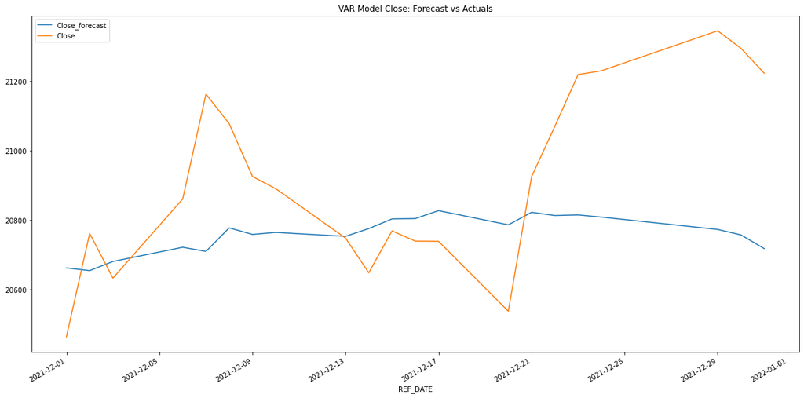

```python
#Plot forecast vs actual

df_results['Close_forecast'].plot(legend=True,title='VAR Model Close: Forecast vs Actuals')
df_test['Close'][-nobs:].plot(legend=True);
plt.show()
```

1. Final Evaluation of the Model

MAPE: Mean Absolute Percentage Error

MAE: Mean Absolute Error

MPE: Mean Percenage Error

RMSE: Root Mean Square Error

CORR: Correlation Coefficent

Coefficient, r

Strength of Association Positive Negative

Small .1 to .3 or -0.1 to -0.3

Medium .3 to .5 or -0.3 to -0.5

Large .5 to 1.0 or -0.5 to -1.0

```python
#Evaluate Forecast
from statsmodels.tsa.stattools import acf
def forecast_accuracy(forecast, actual):
    mape = np.mean(np.abs(forecast - actual)/np.abs(actual))*100  # MAPE
    mae = np.mean(np.abs(forecast - actual))    # MAE
    mpe = np.mean((forecast - actual)/actual)   # MPE
    rmse = np.mean((forecast - actual)**2)**.5  # RMSE
    corr = np.corrcoef(forecast, actual)[0,1]   # corr
    return({'mape':mape, 'mae': mae,
            'mpe': mpe, 'rmse':rmse, 'corr':corr})

print('Forecast Accuracy of: Close')
accuracy_prod = forecast_accuracy(df_results['Close_forecast'].values, df_test['Close'])
for k, v in accuracy_prod.items():
    print(k, ': ', round(v,4))
```

```
Forecast Accuracy of: Close
mape :  1.1077
mae :  233.3787
mpe :  -0.0073
rmse :  291.7252
corr :  0.2512
```

```python
! pwd
```

```
/content
```

```python
%%shell
ipython nbconvert --to html "//content/InitialResult.ipynb"
```